# Lab 3 Assignment: Google Location History

# Extra Credit: Spotify!

This does not work on JupyterHub unfortunately. You have to do this on R and Rstudio on your home computer. I will review it in class, but the lab exercise is extra credit! It is a bit of work to get up and running, but it can be fun to play with your spotify data.

## Necessary Packages

```r
## Run this code, to manage packages and install as needed.
# Install pacman
if (!require("pacman")) install.packages("pacman")
# p_load function loads packages if installed, or install then loads otherwise
pacman::p_load(jsonlite, ggmap,ggplot2, lubridate, zoo,here,tidyverse,kableExtra,ggmap,spotifyr,ggjoy)
```

## Spotify API Access

- See this tutorial for how to acces the API - [spotify R API](https://www.rcharlie.com/spotifyr/).
  - Go to https://developer.spotify.com/dashboard/
  - Log In and accept terms and conditions
  - Create a new app and follow directions on [spotify R API](https://www.rcharlie.com/spotifyr/)

Repeat the analysis below, but for your own data:

```r
Sys.setenv(SPOTIFY_CLIENT_ID = 'YOURKEY')
Sys.setenv(SPOTIFY_CLIENT_SECRET = 'YOURKEY')
access_token <- get_spotify_access_token()
```

```r
########
## If you run the above code and this code
## You wont save your id in Markdown
########
grp<-get_my_recently_played(limit = 5)
gta_st<-get_my_top_artists_or_tracks(type = 'artists', time_range = 'short_term', limit = 5)
gta_lt<-get_my_top_artists_or_tracks(type = 'artists', time_range = 'long_term', limit = 5)
gta_st_tracks<-get_my_top_artists_or_tracks(type = 'tracks', time_range = 'short_term', limit = 5)
gta_lt_tracks<-get_my_top_artists_or_tracks(type = 'tracks', time_range = 'long_term', limit = 5)

ed <- spotifyr::get_artist_audio_features('ed sheeran')

save(grp,gta_st,gta_lt,gta_st_tracks,gta_lt_tracks, ed,file="data/spotify.Rda")
```

```r
################
## Code Examples
################
## Load example data
load(here("data","spotify.Rda"))


grp%>%
  mutate(artist.name = map_chr(track.artists, function(x) x$name[1]),
         played_at = as_datetime(played_at)) %>%
  select(track.name, artist.name, track.album.name, played_at) %>%
  kable()
```

| track.name | artist.name | track.album.name | played_at |
| --- | --- | --- | --- |
| Uptown Funk (feat. Bruno Mars) | Mark Ronson | Uptown Special | 2023-01-21 17:38:42 |
| Blank Space | Taylor Swift | 1989 | 2023-01-21 17:25:01 |
| All About That Bass | Meghan Trainor | All About That Bass | 2023-01-21 17:21:08 |
| Shake It Off | Taylor Swift | 1989 | 2023-01-21 17:17:59 |
| Rude | MAGIC! | Rude | 2023-01-21 17:14:18 |

```r
grp %>%
  mutate(artist.name = map_chr(track.artists, function(x) x$name[1]),
         played_at = as_datetime(played_at)) %>%
  select(track.name, artist.name, track.album.name, played_at) %>%
  kable()
```

| track.name | artist.name | track.album.name | played_at |
| --- | --- | --- | --- |
| Uptown Funk (feat. Bruno Mars) | Mark Ronson | Uptown Special | 2023-01-21 17:38:42 |
| Blank Space | Taylor Swift | 1989 | 2023-01-21 17:25:01 |
| All About That Bass | Meghan Trainor | All About That Bass | 2023-01-21 17:21:08 |
| Shake It Off | Taylor Swift | 1989 | 2023-01-21 17:17:59 |
| Rude | MAGIC! | Rude | 2023-01-21 17:14:18 |

```r
gta_st %>%
  mutate(artist.name = map_chr(artists, function(x) x$name[1])) %>%
  select(name, artist.name, album.name) %>%
  kable()
```

| name | artist.name | album.name |
| --- | --- | --- |
| Peppa’s Lullaby | Peppa Pig | My First Album |
| Gardening With Grandpa | Peppa Pig | Gardening With Grandpa |
| Expert Daddy Pig | Peppa Pig | My First Album |
| Rainbow, Rainbow | Peppa Pig | My First Album |
| Time For Bed | Peppa Pig | Time For Bed |

```r
gta_lt%>%
  select(name, genres) %>%
  rowwise %>%
  mutate(genres = paste(genres, collapse = ', ')) %>%
  ungroup %>%
  kable()
```

| name | genres |
| --- | --- |
| Raffi | canadian children’s music, children’s folk, children’s music |
| Ed Sheeran | pop, uk pop |
| Barenaked Ladies | canadian pop, canadian rock, comic, pop rock |
| Mike Doughty |  |
| Blaze and the Monster Machines | preschool children’s music |

```r
gta_st_tracks %>%
  mutate(artist.name = map_chr(artists, function(x) x$name[1])) %>%
  select(name, artist.name, album.name) %>%
  kable()
```

| name | artist.name | album.name |
| --- | --- | --- |
| Peppa’s Lullaby | Peppa Pig | My First Album |
| Gardening With Grandpa | Peppa Pig | Gardening With Grandpa |
| Expert Daddy Pig | Peppa Pig | My First Album |
| Rainbow, Rainbow | Peppa Pig | My First Album |
| Time For Bed | Peppa Pig | Time For Bed |

```r
ed %>%arrange(-valence) %>%
  select(track_name, valence) %>%
  distinct() %>%
  head(5) %>%
  kable()
```

| track_name | valence |
| --- | --- |
| Bam Bam (feat.Ed Sheeran) | 0.956 |
| Sing | 0.939 |
| Shape of You | 0.931 |
| You Need Me, I Don’t Need You | 0.927 |
| Eraser | 0.914 |

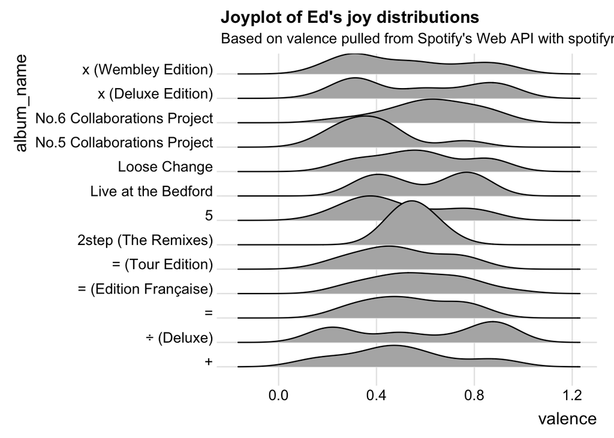

```r
library(ggjoy)

ggplot(ed, aes(x = valence, y = album_name)) +
  geom_joy() +
  theme_joy() +
  ggtitle("Joyplot of Ed's joy distributions", subtitle = "Based on valence pulled from Spotify's Web API with spotifyr")
```